# Analysis of Movie Data

### 4.2 Top 15 Movies Based on Gross and IMDB Score

We might be interested about which movies have the highest gross, so here it is!

seaborn.barplot enables us to plot the given data nicely.

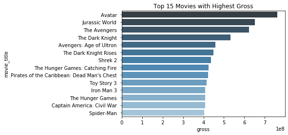

```python
sort_by_gross = movies.sort_values(by=['gross'], ascending=False)
top15 = sort_by_gross.iloc[0:15, :]
ax = seaborn.barplot(y=top15['movie_title'], x=top15['gross'], palette="Blues_d")
ax.set_title("Top 15 Movies with Highest Gross")
```

[figure not shown]

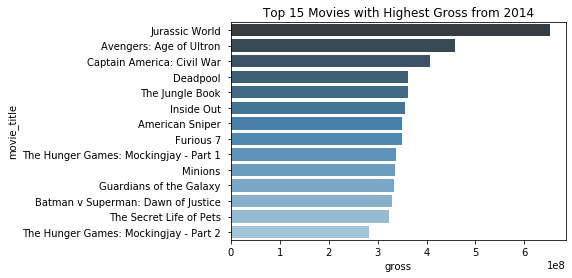

```python
recent_5_years = movies[movies['title_year']>=2014]
sort_by_gross_recent = recent_5_years.sort_values(by=['gross'], ascending=False)
top15_recent = sort_by_gross_recent.iloc[0:15, :]

ax = seaborn.barplot(y=top15_recent['movie_title'], x=top15_recent['gross'], palette="Blues_d")
ax.set_title("Top 15 Movies with Highest Gross from 2014")
```

[figure not shown]

```python
top15_recentgen = top15_recent[['movie_title', 'genres']] # only need these two columns
top15_recentgen.reset_index(drop=True, inplace=True) # reset the index
top15_recentgen.index = top15_recentgen.index + 1 # let index start from 1
top15_recentgen
```

|  | movie_title | genres |
| --- | --- | --- |
| 1 | Jurassic World | Action\|Adventure\|Sci-Fi\|Thriller |
| 2 | Avengers: Age of Ultron | Action\|Adventure\|Sci-Fi |
| 3 | Captain America: Civil War | Action\|Adventure\|Sci-Fi |
| 4 | Deadpool | Action\|Adventure\|Comedy\|Romance\|Sci-Fi |
| 5 | The Jungle Book | Adventure\|Drama\|Family\|Fantasy |
| 6 | The Jungle Book | Adventure\|Drama\|Family\|Fantasy |
| 7 | Inside Out | Adventure\|Animation\|Comedy\|Drama\|Family\|Fantasy |
| 8 | American Sniper | Action\|Biography\|Drama\|History\|Thriller\|War |
| 9 | Furious 7 | Action\|Crime\|Thriller |
| 10 | The Hunger Games: Mockingjay - Part 1 | Adventure\|Sci-Fi\|Thriller |
| 11 | Minions | Action\|Animation\|Comedy\|Family\|Sci-Fi |
| 12 | Guardians of the Galaxy | Action\|Adventure\|Sci-Fi |
| 13 | Batman v Superman: Dawn of Justice | Action\|Adventure\|Sci-Fi |
| 14 | The Secret Life of Pets | Animation\|Comedy\|Family |
| 15 | The Hunger Games: Mockingjay - Part 2 | Adventure\|Sci-Fi |

The table above is top15 highest gross movies and their genres. There are 11 out of 15 are Adventure movies which is the most popular and highest gross movie type. Action films have the same proportion as Sci-fi, which is 9 out of 15. These statistics means that investing Adventure, Action, or Sci-Fi movies is easiest to get high returns.

We also want to see the change of gross over years. We will use mean gross each year as a standard to represent our data, where year is on the x-axis and the mean gross is on the y-axis. A best fit line is provided by linear regression model to show the general trends.

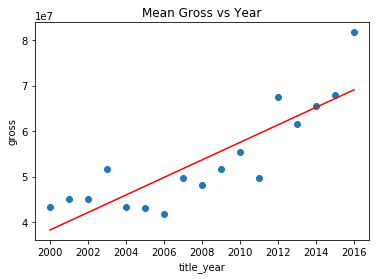

```python
gross_list = []
years = []

for year, j in movies.groupby(['title_year']):
    years.append(year)
    gross_list.append(np.mean(j['gross']))

years = np.asarray(years)
years = years.reshape((-1,1))
gross_list = np.asarray(gross_list)
model2 = LinearRegression().fit(years, gross_list)
aaa1 = years
aaa2 = model2.coef_*aaa1 + model2.intercept_
plt.scatter(years, gross_list)
plt.plot(aaa1, aaa2, color='red')
plt.ylabel('gross')
plt.xlabel('title_year')
plt.title("Mean Gross vs Year")
plt.show()
```

From the plot and the best fit line, we can see the mean gross generally increases each year. This can be the result of many factors, like people's improvements on life standard and better film making technologies.

### 4.2 Analysis on Genres

### Distribution of Genres Over Years:

Next we will take a look at how the genres were distributed in each year. More specifically, for each genre, we will calculate the number of movies that the genre is categorized into annually. To do this, we need to collect information from the dataframe and process it.

As the dataframe was displayed above, we can see that the 'genres' category contains a collection of genres for each movie, so it's time to split them! In the meantime, we can add them to a set of genres, which is useful for later analysis.

```python
genres = []
genre_set = set()

for g in movies['genres']:
  splitted = g.split('|')
  genres.append(splitted)
  for i in splitted:
    genre_set.add(i)

#movies['genres'] = genres
movies.loc[:, 'genres'] = genres
movies.head()
```

|  | movie_title | genres | title_year | imdb_score | budget | gross | overall_facebook_likes | num_critic_for_reviews | num_user_for_reviews | language | country | plot_keywords | num_voted_users | rounded_score |
| --- | --- | --- | --- | --- | --- | --- | --- | --- | --- | --- | --- | --- | --- | --- |
| 0 | Avatar | [Action, Adventure, Fantasy, Sci-Fi] | 2009.0 | 7.9 | 237000000.0 | 760505847.0 | 35791.0 | 723.0 | 3054.0 | English | USA | avatar\|future\|marine\|native\|paraplegic | 886204 | 8 |
| 1 | Pirates of the Caribbean: At World's End | [Action, Adventure, Fantasy] | 2007.0 | 7.1 | 300000000.0 | 309404152.0 | 46563.0 | 302.0 | 1238.0 | English | USA | goddess\|marriage ceremony\|marriage proposal\|pi... | 471220 | 7 |
| 2 | Spectre | [Action, Adventure, Thriller] | 2015.0 | 6.8 | 245000000.0 | 200074175.0 | 96554.0 | 602.0 | 994.0 | English | UK | bomb\|espionage\|sequel\|spy\|terrorist | 275868 | 7 |
| 3 | The Dark Knight Rises | [Action, Thriller] | 2012.0 | 8.5 | 250000000.0 | 448130642.0 | 259000.0 | 813.0 | 2701.0 | English | USA | deception\|imprisonment\|lawlessness\|police offi... | 1144337 | 8 |
| 5 | John Carter | [Action, Adventure, Sci-Fi] | 2012.0 | 6.6 | 263700000.0 | 73058679.0 | 26277.0 | 462.0 | 738.0 | English | USA | alien\|american civil war\|male nipple\|mars\|prin... | 212204 | 7 |

After we have the 'genres' holding lists of genres, we can do some calculation. The for loop after initialization computes sums, and the next one makes a lineplot accordingly.

(The default colors for line plots are not sufficient for our long list of genres. So, to avoid duplicates of color representation of the lines, we used the rainbow function from matplotlib.cm to generate unique rainbow colors for each genre.)

```
No handles with labels found to put in legend.
```

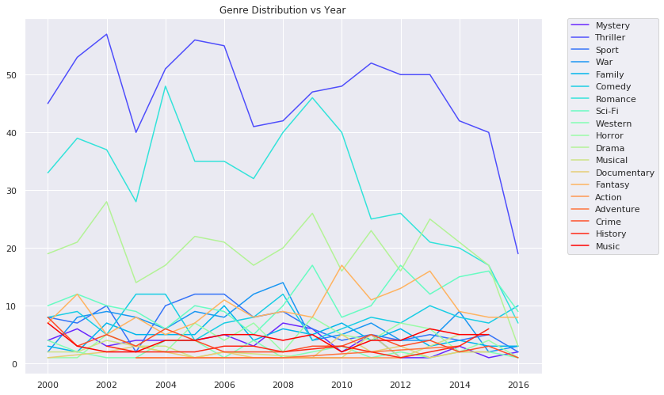

```python
# initialization
genres_totalCount = dict()
genres_hash = dict()
years_total = dict()
for i in genre_set:
    genres_hash[i] = dict()
for i in movies['title_year'].unique():
    years_total[i] = 0

# sums up number of genre appearence each year
for i, j in movies.iterrows():
    for genre in j['genres']:
        if genre in genres_totalCount:
            genres_totalCount[genre] += 1
        else:
            genres_totalCount[genre] = 1
        years_total[j['title_year']] += 1
    if j['title_year'] in genres_hash[genre]:
        genres_hash[genre][j['title_year']] += 1
    else:
        genres_hash[genre][j['title_year']] = 1

cnt = 0
colors = cm.rainbow(np.linspace(0, 1, len(genre_set)))
for genre, years_cnt in genres_hash.items():
    years = list(years_cnt.keys())
    counts = list(years_cnt.values())

    seaborn.set(rc={'figure.figsize':(11.7,8.27)})
    ax = seaborn.lineplot(x=years, y=counts, label=genre, c=colors[cnt])
    ax.set_title("Genre Distribution vs Year")
    ax.legend(bbox_to_anchor=(1.05, 1), loc=2, borderaxespad=0.)
    cnt += 1
```

A pie chart is also plotted to make a better visualization of the major distribution of the genres. To make such pie chart, a new DataFrame is created so that genres can be stored as index of the DataFrame and total counts of each genre are stored in column.

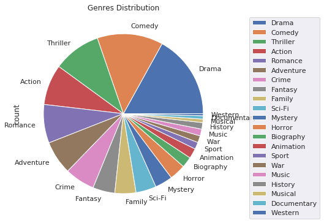

```python
genres_col = []
count_col = []

for genre, count in genres_totalCount.items():
    genres_col.append(genre)
    count_col.append(count)

# Create a new DataFrame with index being genres and one column holding total counts
genres_ranking = pd.DataFrame({'count': count_col}, index=genres_col)

genres_ranking = genres_ranking.sort_values(by='count', ascending=False)
genres_ranking.plot.pie(y='count', figsize = (6,6), title="Genres Distribution").legend(bbox_to_anchor=(1.5, 1))
```

It turns out that simply using the number of occurrence of the genres in all movies is not the best way to describe distribution over years since the number of movies each year recorded in the dataset varies. As a result, the trend of each genre's over year might be misleading. So intead, we will calculate the ratio that a specific genre appears in movies with respect to the number of movies recorded each year.

```
No handles with labels found to put in legend.
```

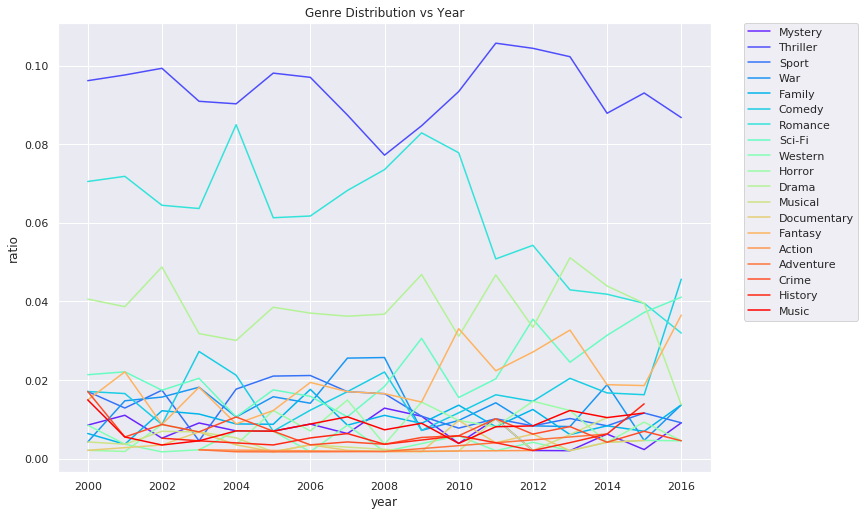

```python
cnt = 0
for genre, years_cnt in genres_hash.items():
    years = list(years_cnt.keys())
    counts = list(years_cnt.values())
    ratio = []

    # Compute genres' ratio
    for i in range(len(years)):
        ratio.append(counts[i] / years_total[years[i]])

    seaborn.set(rc={'figure.figsize':(11.7,8.27)})
    ax = seaborn.lineplot(x=years, y=ratio, label=genre, c=colors[cnt])
    ax.legend(bbox_to_anchor=(1.05, 1), loc=2, borderaxespad=0.)
    ax.set_title("Genre Distribution vs Year")
    ax.set(xlabel='year', ylabel='ratio')
    cnt += 1
```

We can even do more cool visualization with fancy tools like WordCloud! The following the an example of generating a picture of occurence of genres in the entire dataset. More common genres have larger font sizes.

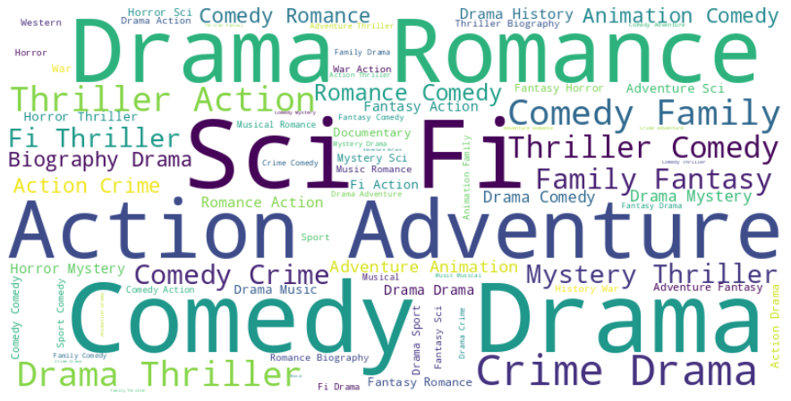

```python
genres_all = []

# Collect all genre appearance into a single list
for i, j in movies.iterrows():
    genres_all.extend(j['genres'])

wc = WordCloud( width=800,
                height=400,
                background_color="white",
                max_words=500,
                max_font_size=100,
                random_state=12)

# Join the strings with a space
lis = ' '.join(genres_all)

# Generate word cloud
wc.generate(lis)

plt.figure(figsize=(16, 8))
plt.imshow(wc, interpolation='bilinear')

plt.axis("off")
plt.show()
```

### 4.3 Popularity / Facebook Likes

Of course people would like to watch a movie directed by their favorite director, or the one with their favorite actors involved. So popularity of director or actors of the movies might directly relate to its gross, and that's going to be our next step. In this section, we are going to find and discuss the relationship between a movie's gross and the popularity of its director and main actors. There can be various ways to represent popularity, and we choose to use the number of facebook likes. In the previous sections, we extracted and combined the facebook likes of the movie itself, director, actor 1, actor 2, and actor 3. So we can start from there!

```
'c' argument looks like a single numeric RGB or RGBA sequence, which should be avoided as value-mapping will have precedence in case its length matches with 'x' & 'y'.  Please use a 2-D array with a single row if you really want to specify the same RGB or RGBA value for all points.
```

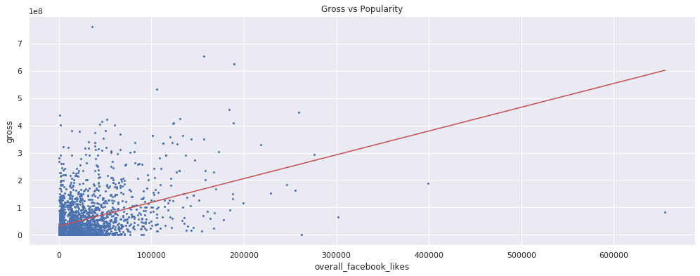

```python
popularity_plot = movies[['gross', 'overall_facebook_likes']]
popularity_plot.plot(kind = 'scatter', y = 'gross', x = 'overall_facebook_likes',s=4, figsize = (17,6), title = "Gross vs Popularity" )
model = LinearRegression()
model.fit(movies[['overall_facebook_likes']],movies['gross'])
aa1 = np.linspace(min(movies['overall_facebook_likes']),max(movies['overall_facebook_likes']),100)
aa2 = model.coef_*aa1 + model.intercept_
plt.plot(aa1, aa2, color='r')
```

A clearer visualization of the data is given below by removing the outliers with director and actors' combined facebook likes exceeding 200000. Later numerical analysis will still be operated on the original data.

```
'c' argument looks like a single numeric RGB or RGBA sequence, which should be avoided as value-mapping will have precedence in case its length matches with 'x' & 'y'.  Please use a 2-D array with a single row if you really want to specify the same RGB or RGBA value for all points.
```

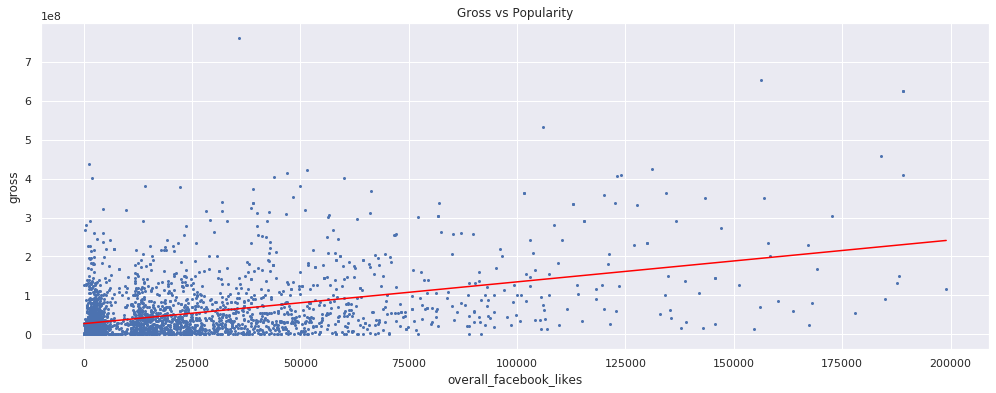

```python
movies_modified = movies[movies['overall_facebook_likes'] < 200000]
popularity_plot = movies_modified[['gross', 'overall_facebook_likes']]
popularity_plot.plot(kind = 'scatter', y = 'gross', x = 'overall_facebook_likes',s=4, figsize = (17,6), title = "Gross vs Popularity" )
model = LinearRegression()
model.fit(movies_modified[['overall_facebook_likes']],movies_modified['gross'])
aa1 = np.linspace(min(movies_modified['overall_facebook_likes']),max(movies_modified['overall_facebook_likes']),100)
aa2 = model.coef_*aa1 + model.intercept_
plt.plot(aa1, aa2, color='red')
```

## 5. Comparing Gross and IMDB Score with Regression

### 5.1 Linear Regression with Interactive Terms

From all of our previous exploration on the data with respect to the relationship between several factors and the gross, there's no significant findings since the correlations seem to be very weak. We believe that there has to be some way, might be interactive, that these factor, when measured together, contribute to the gross or the IMDB score.

$g(i)$ gives the specific genre in the genre_set.

$g(i)$ gives the specific genre in the genre_set, and the genre_set is shown below:

```python
list(genre_set)
```

```
['Animation',
 'Mystery',
 'Thriller',
 'Sport',
 'War',
 'Family',
 'Comedy',
 'Romance',
 'Biography',
 'Sci-Fi',
 'Western',
 'Horror',
 'Drama',
 'Musical',
 'Documentary',
 'Fantasy',
 'Action',
 'Adventure',
 'Crime',
 'History',
 'Music']
```

The genres of each movie is computed with 0 and 1, and the interactive term is computed with the genre vector multiplied by the year. Then we create a new dataframe with only independent and dependent variables needed in the equation.

```python
# Initialization
genres_list = []
inter_list = []
X = []

for i, j in movies.iterrows():
    glst = []
    for idx in range(len(genre_set)):
        l = list(genre_set)

        # glst computes genres vector
        if l[idx] in j['genres']:
            glst.append(1)
        else:
            glst.append(0)

    # inter_list adds interactive terms
    inter_term = [x * j['title_year'] for x in glst]
    inter_list.append(inter_term)
    genres_list.append(glst)
    xlst = list()
    xlst.append(j['title_year'])
    xlst.append(j['overall_facebook_likes'])
    xlst.extend(glst)
    xlst.extend(inter_term)
    X.append(xlst)


df = pd.DataFrame({'year':movies['title_year'], 'popularity':movies['overall_facebook_likes'], 'genres':genres_list,
                  'genre_year':inter_list,'dependent_vars': X, 'gross':movies['gross'], 'imdb_score':movies['imdb_score']})
df.head()
```

|  | year | popularity | genres | genre_year | dependent_vars | gross | imdb_score |
| --- | --- | --- | --- | --- | --- | --- | --- |
| 0 | 2009.0 | 35791.0 | [0, 0, 0, 0, 0, 0, 0, 0, 0, 1, 0, 0, 0, 0, 0, ... | [0.0, 0.0, 0.0, 0.0, 0.0, 0.0, 0.0, 0.0, 0.0, ... | [2009.0, 35791.0, 0, 0, 0, 0, 0, 0, 0, 0, 0, 1... | 760505847.0 | 7.9 |
| 1 | 2007.0 | 46563.0 | [0, 0, 0, 0, 0, 0, 0, 0, 0, 0, 0, 0, 0, 0, 0, ... | [0.0, 0.0, 0.0, 0.0, 0.0, 0.0, 0.0, 0.0, 0.0, ... | [2007.0, 46563.0, 0, 0, 0, 0, 0, 0, 0, 0, 0, 0... | 309404152.0 | 7.1 |
| 2 | 2015.0 | 96554.0 | [0, 0, 1, 0, 0, 0, 0, 0, 0, 0, 0, 0, 0, 0, 0, ... | [0.0, 0.0, 2015.0, 0.0, 0.0, 0.0, 0.0, 0.0, 0.... | [2015.0, 96554.0, 0, 0, 1, 0, 0, 0, 0, 0, 0, 0... | 200074175.0 | 6.8 |
| 3 | 2012.0 | 259000.0 | [0, 0, 1, 0, 0, 0, 0, 0, 0, 0, 0, 0, 0, 0, 0, ... | [0.0, 0.0, 2012.0, 0.0, 0.0, 0.0, 0.0, 0.0, 0.... | [2012.0, 259000.0, 0, 0, 1, 0, 0, 0, 0, 0, 0, ... | 448130642.0 | 8.5 |
| 5 | 2012.0 | 26277.0 | [0, 0, 0, 0, 0, 0, 0, 0, 0, 1, 0, 0, 0, 0, 0, ... | [0.0, 0.0, 0.0, 0.0, 0.0, 0.0, 0.0, 0.0, 0.0, ... | [2012.0, 26277.0, 0, 0, 0, 0, 0, 0, 0, 0, 0, 1... | 73058679.0 | 6.6 |

Now we calculate 2 linear regressions with identical independent variables using LinearRegression(). One dependent variable is gross and the other is IMDB score. These regressions enable us to predict a movie's gross or IMDB score if given the indenpendent vector. The coefficients of the 2 linear regressions are shown:

```python
# Fit linear regression
y = df['gross']
reg_gross = LinearRegression().fit(X, y)
print(reg_gross.score(X, y))
reg_gross.coef_
```

```
0.3635715296491495
```

```
array([-1.02056746e+06,  7.83690506e+02, -7.03668138e+09,  3.58948342e+09,
       -3.21248171e+08, -6.69919130e+08, -2.80760357e+09,  8.71273475e+07,
       -1.45254161e+09, -1.75445801e+07, -8.93101315e+07, -6.18877731e+09,
        2.95709680e+08,  5.44842364e+07,  1.65178540e+09, -2.14554694e+09,
        4.21900839e+09,  4.37124501e+09,  3.03408512e+09, -2.17610504e+09,
       -1.17971308e+09,  4.05482996e+08, -1.99840592e+09,  3.51313994e+06,
       -1.78704687e+06,  1.57295788e+05,  3.36002467e+05,  1.39517894e+06,
       -3.61360028e+04,  7.20965717e+05,  1.02505201e+04,  4.37773584e+04,
        3.08499050e+06, -1.61304038e+05, -3.41047036e+04, -8.32633721e+05,
        1.06555265e+06, -2.11054272e+06, -2.16905108e+06, -1.50188761e+06,
        1.10060719e+06,  5.84365094e+05, -2.00943545e+05,  9.98801275e+05])
```

```python
y = df['imdb_score']
reg_score = LinearRegression().fit(X, y)
print(reg_score.score(X, y))
reg_score.coef_
```

```
0.2931048851946494
```

```
array([-4.68079963e-02,  8.98209261e-06,  2.93432909e+01, -9.55573802e+00,
       -4.15956248e+01, -8.55883335e+01, -5.81281557e+01, -8.01268437e+01,
       -7.60336682e+01, -4.74735141e+01, -3.54950981e+01, -3.75567471e+01,
       -4.07304395e+01, -4.75124615e+01,  3.83786217e+01,  6.45267806e+01,
       -2.86181115e+01,  3.80501897e+01,  5.22651125e+00, -2.56821791e+01,
       -3.00938793e+01,  2.07660186e+01, -1.65805494e+01, -1.42453756e-02,
        4.80257511e-03,  2.06271056e-02,  4.26332267e-02,  2.90103674e-02,
        3.97915738e-02,  3.77006242e-02,  2.36247045e-02,  1.77713380e-02,
        1.86922832e-02,  2.01872989e-02,  2.34442871e-02, -1.88640384e-02,
       -3.22131778e-02,  1.46123372e-02, -1.90221607e-02, -2.68268245e-03,
        1.28489508e-02,  1.50556892e-02, -1.02496548e-02,  8.13457407e-03])
```

The correlation coefficients turned out to be not as high as expected, so the linear regressions only suggest a relatively weak correlation between the indepedent variable and dependent variable.

However, we can still gain other intuition from the coefficients of the 2 models. By looking at the coefficients, we can see obvious differences, and this indicates that factors are weighted differently in determining gross and IMDB scores.

### 5.2 T-Test on the regressions

We can also make a t test with 2 sets of coefficients for comparison:

```python
stats.ttest_rel(reg_gross.coef_, reg_score.coef_)
```

```
Ttest_relResult(statistic=-0.6283370040497186, pvalue=0.5331066040606598)
```

## 6. Conclusion

We failed to compute a very precise model to determine either gross or the IMDB score this time, but this field is worth exploring. There exist too many factors which might influence a movie's quality, either measured with gross or IMDB score. These factors can include larger-scale ones like the overall economic situation of the era, or change of people's aethetic standard overtime. Some of these are hard to determine, and further data exploration and analysis can be made on other potential factors or models.